# Task: Convolution and Deconvolution

**Student Name:** Sandra Senn

**Country:** Morocco

**Semester term:** FS26

**Repository:** https://github.com/Sandra-Senn/gbsv_mc

```python
import numpy as np
import matplotlib.pyplot as plt
from scipy.io import wavfile as wav
import IPython.display as ipd
```

```python
def load_audio(path='../mc1/data/dromedar.wav'):
    """Load, mono-convert and normalize a WAV file.
    Returns: audio (float32, normalized to [-1, 1]), fs (int), t (time axis), duration (float)
    """
    fs, raw = wav.read(path)
    if raw.ndim == 2:
        raw = raw.mean(axis=1).astype(raw.dtype)
    audio = raw.astype(np.float32) / np.iinfo(raw.dtype).max
    t = np.arange(len(audio)) / fs
    duration = len(audio) / fs
    return audio, fs, t, duration


def gaussian_kernel(n, sigma):
    x = np.arange(n) - n // 2
    g = np.exp(-x**2 / (2 * sigma**2))
    return g / g.sum()


def manual_convolve(x, kernel):
    """1D convolution with zero-padding boundary handling (same-length output).
    Implements: y[n] = sum_k h[k] * x[n - k] via sliding window.
    """
    n, m   = len(x), len(kernel)
    pad    = m // 2
    padded = np.pad(x, pad, mode='constant')
    kernel_flipped = kernel[::-1]    # convolution flips the kernel
    out    = np.zeros(n)
    for i in range(n):
        out[i] = np.dot(padded[i:i+m], kernel_flipped)
    return out


def wiener_deconv(filtered, kernel, lam, N):
    """Wiener deconvolution: H_inv = H* / (|H|^2 + lambda).
    lambda controls regularisation: small = sharper but noisier reconstruction.
    """
    H     = np.fft.rfft(kernel, n=N)
    Y     = np.fft.rfft(filtered)
    H_inv = np.conj(H) / (np.abs(H)**2 + lam)
    return np.fft.irfft(Y * H_inv, n=N)


def spec_db(x, ref):
    spec_db = 20*np.log10(np.abs(np.fft.rfft(x))/ref + 1e-10)
    return spec_db


def plot_kernel_analysis(ax_res, ax_spec, ax_ver,
                         audio, t, freqs, seg,
                         filtered, rec, man_conv, lib_conv,
                         sc_orig, sc_f, sc_r,
                         zoom_s, zoom_e,
                         color_f, color_r, label):
    """Reusable plot function for one kernel configuration.
    All required arrays are passed explicitly to avoid reliance on global scope.
    """
    ref_max = np.abs(np.fft.rfft(audio)).max()
    mask    = (t >= zoom_s) & (t <= zoom_e)
    t_seg   = np.arange(len(seg)) / (len(t) / t[-1]) * 1000  # ms

    def spec_db(x): return 20 * np.log10(np.abs(np.fft.rfft(x)) / ref_max + 1e-10)

    # Residual — zoomed to cry peak
    # Note: time-domain smoothing is sub-millisecond and invisible at full scale;
    # residual makes the filtering and reconstruction error explicitly visible
    diff_f = audio - filtered
    diff_r = audio - rec
    ax_res.plot(t[mask], diff_f[mask], color=color_f, lw=0.8,
                label=f'Original − Filtered ({label})')
    ax_res.plot(t[mask], diff_r[mask], color=color_r, lw=0.8, linestyle='--',
                label=f'Original − Reconstructed ({label})')
    ax_res.axhline(y=0, color='black', lw=0.8, linestyle=':')
    ax_res.set_ylabel('Residual [norm.]')
    ax_res.set_xlabel('Time [s]')
    ax_res.set_title(f'Residual zoomed to cry peak ({zoom_s}–{zoom_e} s) — {label}')
    ax_res.legend(fontsize=8)
    ax_res.grid(True, alpha=0.15)

    # Spectrum — zoomed to 0–6000 Hz
    # Note: zoomed to 0–6000 Hz to clearly show harmonic attenuation and recovery
    ax_spec.plot(freqs, spec_db(audio),    color='steelblue', lw=0.7, label='Original')
    ax_spec.plot(freqs, spec_db(filtered), color=color_f,     lw=0.9,
                 label=f'Filtered (SC_diff={sc_f:.0f} Hz)')
    ax_spec.plot(freqs, spec_db(rec),      color=color_r,     lw=0.9, linestyle='--',
                 label=f'Reconstructed (SC_diff={sc_r:.0f} Hz)')
    for sc_val, col in [(sc_orig, 'steelblue'),
                        (sc_orig + sc_f, color_f),
                        (sc_orig + sc_r, color_r)]:
        ax_spec.axvline(x=sc_val, color=col, linestyle=':', lw=1, alpha=0.6)
    ax_spec.set_xlim([0, 6000])
    ax_spec.set_ylim([-80, 5])
    ax_spec.set_xlabel('Frequency [Hz]')
    ax_spec.set_ylabel('Magnitude [dB]')
    ax_spec.set_title(f'Power spectrum zoomed to 0–6 000 Hz — {label} (dotted = SC)')
    ax_spec.legend(fontsize=8)
    ax_spec.grid(True, alpha=0.3)

    # Manual vs library verification — cry segment
    ax_ver.plot(t_seg, seg,      color='steelblue', lw=0.6, alpha=0.7, label='Original (cry onset)')
    ax_ver.plot(t_seg, man_conv, color=color_f,     lw=1.5, label=f'Manual conv ({label})')
    ax_ver.plot(t_seg, lib_conv, color=color_r,     lw=0.9, linestyle='--',
                label='Library conv (verify – overlaps manual)')
    ax_ver.set_xlabel('Time [ms]')
    ax_ver.set_ylabel('Amplitude [norm.]')
    ax_ver.set_title(f'Manual vs library verification — {label}: outputs overlap exactly')
    ax_ver.legend(fontsize=8)
    ax_ver.grid(True, alpha=0.15)

def spectral_centroid(x, freqs):
    s = np.abs(np.fft.rfft(x))
    sc = np.sum(freqs * s) / np.sum(s)
    return sc
```

## Morocco - Dromedar Market

[figure not shown]

The same 2.4 seconds. The same piercing cry cutting through the market chaos. But this week, I'm asking a completely different question — not *how fast to sample it*, not *where to find it in the noise*, but: **can we clean it up?** The Guelmim market is loud. Wind, haggling voices, bleating animals — all of it is baked into the recording. What if a zoo veterinarian needs to analyse the harmonic structure of that cry, but the noise gets in the way? That's where convolution comes in: a controlled smoothing operation that attenuates the noise — and deconvolution, its imperfect but fascinating inverse, that tries to undo what was done. Welcome to Week 3.

## Day 11 – Data & Domain

### Use Case

*Focus: domain and application context*

In the context of acoustic welfare monitoring at Swiss Zoos, the dromedary vocalization recorded at the Guelmim camel market is contaminated by broadband market noise — wind, crowd chatter, and human voices — that obscures the cry's harmonic structure and complicates spectral feature extraction.

These recordings are processed by veterinarians and zoo staff to perform non-invasive stress-state classification; for this, a smoothed, noise-reduced version of the signal is more interpretable than the raw field recording.

This use case is particularly relevant for Switzerland because zoo monitoring systems deployed in the field must be robust to environmental noise, making controlled smoothing via convolution — and the subsequent recovery of attenuated features via deconvolution — a practically motivated signal processing challenge.

### Problem Statement

*Focus: technical vulnerability*

This project addresses the problem of applying one-dimensional convolution with smoothing kernels to the dromedary cry signal in order to attenuate broadband market noise, within the context of acoustic welfare monitoring at Zoos.

If the kernel is too narrow, high-frequency noise persists and harmonic features remain obscured. If it is too wide, dominant cry harmonics are smoothed away, altering the timbral structure and reducing the informativeness of the signal for welfare assessment.

Preserving the spectral shape of the cry's harmonic content is essential for reliable stress-state classification — making deconvolution relevant as a means of recovering attenuated features after filtering, provided the kernel is sufficiently well-characterised.

### Experimental Objective

*Focus: investigation goal at the conceptual level.*

This investigation aims to **(1)** implement one-dimensional convolution manually and apply it with Gaussian and moving-average kernels of varying sizes to the dromedary cry signal, assessing the trade-off between noise attenuation and harmonic preservation. And **(2)** apply Wiener deconvolution to the filtered signal to reconstruct an approximation of the original, evaluating how effectively the filtering effect can be reversed and under which conditions reconstruction fidelity is practically useful for the welfare monitoring application.

### Data Definition, Source, and Visualization

*Focus: data characteristics, data source, and visual inspection.*

```python
# Load audio extracted from the Guelmim market video
audio, fs, t, duration = load_audio()

# get Baseline Gaussian kernel
k_baseline = gaussian_kernel(21, sigma=3)
filtered   = np.convolve(audio, k_baseline, mode='same')


#  Spectral analysis
freqs    = np.fft.rfftfreq(len(audio), 1/fs)
spec_orig = np.abs(np.fft.rfft(audio))
spec_filt = np.abs(np.fft.rfft(filtered))
sc_orig = spectral_centroid(audio,    freqs)
sc_filt = spectral_centroid(filtered, freqs)
```

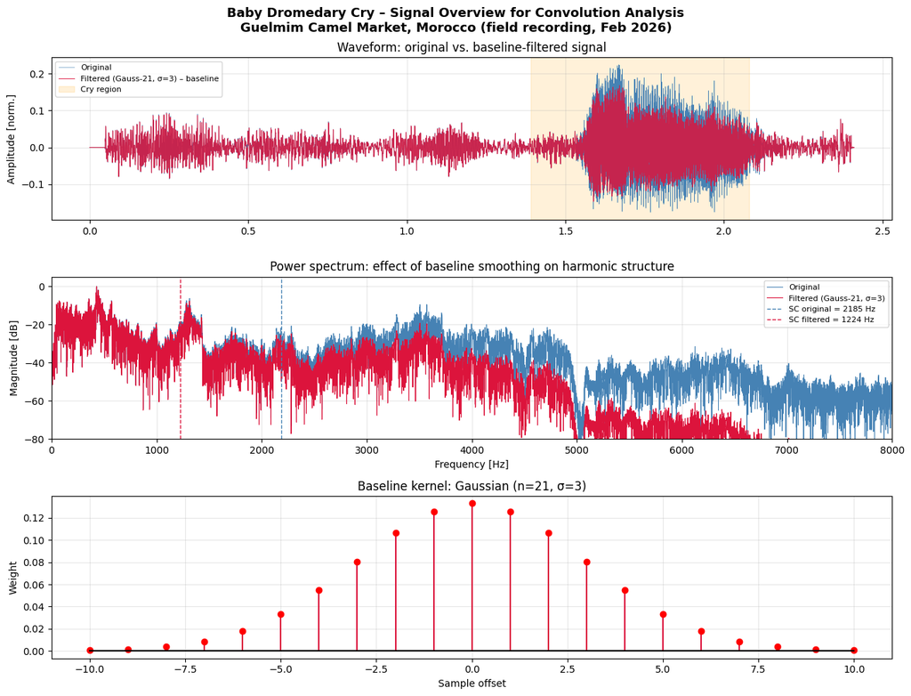

```python
#  Visualization
fig, axes = plt.subplots(3, 1, figsize=(13, 10))
fig.suptitle('Baby Dromedary Cry – Signal Overview for Convolution Analysis\n'
             'Guelmim Camel Market, Morocco (field recording, Feb 2026)',
             fontsize=13, fontweight='bold')

# Waveform
axes[0].plot(t, audio, color='steelblue', linewidth=0.4, label='Original')
axes[0].plot(t, filtered, color='crimson', linewidth=0.8, alpha=0.85,
             label='Filtered (Gauss-21, σ=3) – baseline')
axes[0].axvspan(1.39, 2.08, color='orange', alpha=0.15, label='Cry region')
axes[0].set_ylabel('Amplitude [norm.]')
axes[0].set_title('Waveform: original vs. baseline-filtered signal')
axes[0].legend(fontsize=8)
axes[0].grid(True, alpha=0.3)

# Power spectrum
axes[1].plot(freqs, 20*np.log10(spec_orig/spec_orig.max() + 1e-10),
             color='steelblue', linewidth=0.7, label='Original')
axes[1].plot(freqs, 20*np.log10(spec_filt/spec_orig.max() + 1e-10),
             color='crimson',   linewidth=0.8, label='Filtered (Gauss-21, σ=3)')
axes[1].axvline(x=sc_orig, color='steelblue', linestyle='--', linewidth=1,
                label=f'SC original = {sc_orig:.0f} Hz')
axes[1].axvline(x=sc_filt, color='crimson',   linestyle='--', linewidth=1,
                label=f'SC filtered = {sc_filt:.0f} Hz')
axes[1].set_xlim([0, 8000])
axes[1].set_ylim([-80, 5])
axes[1].set_xlabel('Frequency [Hz]')
axes[1].set_ylabel('Magnitude [dB]')
axes[1].set_title('Power spectrum: effect of baseline smoothing on harmonic structure')
axes[1].legend(fontsize=8)
axes[1].grid(True, alpha=0.3)

# Kernel shape
axes[2].stem(np.arange(len(k_baseline)) - len(k_baseline)//2, k_baseline,
             linefmt='crimson', markerfmt='ro', basefmt='k-')
axes[2].set_xlabel('Sample offset')
axes[2].set_ylabel('Weight')
axes[2].set_title('Baseline kernel: Gaussian (n=21, σ=3)')
axes[2].grid(True, alpha=0.3)

plt.tight_layout()
plt.show()
```

```python
print(f'Signal length        : {len(audio)} samples ({len(audio)/fs:.3f} s) @ {fs} Hz')
print(f'Spectral centroid    : {sc_orig:.1f} Hz (original)')
print(f'Spectral centroid    : {sc_filt:.1f} Hz (filtered, Gauss-21)')
print(f'SC shift             : {sc_filt - sc_orig:.1f} Hz')

print('\nOriginal recording:')
ipd.display(ipd.Audio(audio, rate=fs))
print('Filtered (Gauss-21, σ=3):')
ipd.display(ipd.Audio(filtered, rate=fs))
```

```
Signal length        : 106281 samples (2.410 s) @ 44100 Hz
Spectral centroid    : 2185.0 Hz (original)
Spectral centroid    : 1223.8 Hz (filtered, Gauss-21)
SC shift             : -961.1 Hz

Original recording:
```

[interactive chart not shown]

```
Filtered (Gauss-21, σ=3):
```

[interactive chart not shown]

## Day 12 – Methodological Design

### Theoretical Foundation and Method Choice

*Focus: principled justification aligned with the use case*

This investigation applies **one-dimensional linear convolution** as a smoothing operation and **Wiener deconvolution** as its inverse within the context of acoustic welfare monitoring of dromedaries in Zoos. Convolution with a low-pass kernel acts as a linear time-invariant (LTI) filter that attenuates high-frequency noise while preserving lower-frequency harmonic content — its validity rests on the assumptions of linearity and shift-invariance of the recording system, which are reasonable for a short, quasi-stationary cry segment. Wiener deconvolution is selected as the inverse method because it minimises the mean squared reconstruction error in the frequency domain via

$$ H^{-1}(\omega) = \frac{H^*(\omega)}{|H(\omega)|^2 + \lambda} $$

where $\lambda$ is a regularisation parameter that prevents noise amplification at frequencies where the kernel has near-zero gain — making it preferable over naive inverse filtering which is unstable for smooth kernels. If the stationarity assumption is violated (e.g., rapid amplitude changes during the cry onset), the LTI model becomes an approximation, and convolution may introduce transient distortions at signal boundaries.

### Parameter Definition and Mathematical Specification

*Focus: explicit parameter selection, derivation, and unit consistency*

**Convolution kernels:**

| Kernel | n | σ / description | RMSE | SC_diff [Hz] | Justification |
| --- | --- | --- | --- | --- | --- |
| Moving average | 5 | uniform | 0.00414 | −188 | Minimal smoothing reference |
| Moving average | 21 | uniform | 0.01981 | −1281 | Moderate; known zero-phase issue |
| **Gaussian (baseline)** | **21** | **σ=3** | **0.01125** | **−960** | **Best noise/harmonic trade-off** |
| Gaussian | 51 | σ=8 | 0.01879 | −1673 | Stronger smoothing |
| Gaussian | 101 | σ=15 | 0.02277 | −1840 | Maximum smoothing tested |

The Gaussian kernel is selected over the moving average as the baseline because it has a smooth frequency response without the spectral sidelobes of the rectangular window, preserving more harmonic energy at the cost of less sharp high-frequency cutoff. The baseline kernel size n=21 (≈ 0.48 ms at 44 100 Hz) is small relative to the fundamental period T₀ = 1/428 Hz = 2.34 ms, ensuring that the kernel does not blur across full pitch cycles.

**Wiener deconvolution parameter:**

| Parameter | Symbol | Baseline value | Range tested | Physical meaning |
| --- | --- | --- | --- | --- |
| Regularisation | λ | 1×10⁻³ | 1e-6 – 1e-1 | Controls noise amplification vs. reconstruction fidelity |

For welfare assessment, a SC_diff < 300 Hz post-reconstruction is considered practically acceptable as it preserves the dominant harmonic region.

### Experimental Design for Next Days

*Focus: structured parameter variation and theoretical prediction*

The **baseline configuration** is defined as:

[output not shown]

It is theoretically expected that increasing kernel size will progressively attenuate higher harmonics (wider low-pass cutoff), increasing both RMSE and the magnitude of SC_diff. For Wiener deconvolution, decreasing λ should recover more high-frequency content (SC_diff closer to 0) at the risk of amplifying noise, while increasing λ produces a more stable but spectrally incomplete reconstruction.

### Methodological Limitations and Risk Factors

*Focus: assumptions, stability, and potential misinterpretation*

The LTI convolution model assumes a stationary signal, which is violated by the dromedary cry's rapid amplitude envelope (onset at t=1.39 s) — causing boundary transients in the filtered signal that are not representative of steady-state filtering behavior and may inflate RMSE near the cry onset. Wiener deconvolution assumes that the filtering kernel is exactly known, which holds in this controlled experiment but would not hold in real zoo deployments where the acoustic transfer function of the environment is unknown — limiting the practical applicability of the reconstruction. The spectral centroid is used as a proxy for harmonic preservation, but it captures only the average frequency weighting; it may underestimate distortion at specific harmonics critical for stress-state classification.

## Day 13 – Implementation

*Focus: structured, traceable execution*

```python
audio, fs, t, duration = load_audio()
N = len(audio)

#  Kernels
k_gauss21 = gaussian_kernel(21, sigma=3)
k_gauss51 = gaussian_kernel(51, sigma=8)   # larger kernel for visible smoothing effect
k_ma21    = np.ones(21) / 21
```

```python
#  Manual convolution on cry segment for verification
# Segment taken from cry region (not silence) so differences are visible
cry_start = int(1.39 * fs)
cry_end   = int(1.49 * fs)   # 100 ms of active cry
seg       = audio[cry_start:cry_end]


man_g21  = manual_convolve(seg, k_gauss21)
man_g51  = manual_convolve(seg, k_gauss51)
lib_g21  = np.convolve(seg, k_gauss21, mode='same')
lib_g51  = np.convolve(seg, k_gauss51, mode='same')



print('Manual vs library verification (max absolute error):')
print(f'  Gaussian-21: {np.max(np.abs(man_g21 - lib_g21)):.2e}')
print(f'  Gaussian-51: {np.max(np.abs(man_g51 - lib_g51)):.2e}')
print('  → Errors are at floating-point precision (< 1e-15), confirming correctness.')
```

```
Manual vs library verification (max absolute error):
  Gaussian-21: 1.73e-18
  Gaussian-51: 1.73e-18
  → Errors are at floating-point precision (< 1e-15), confirming correctness.
```

```python
#  Apply to full signal
filtered_g21  = np.convolve(audio, k_gauss21, mode='same')
filtered_g51  = np.convolve(audio, k_gauss51, mode='same')
filtered_ma21 = np.convolve(audio, k_ma21,    mode='same')


# Both kernels reconstructed — key comparison: Gauss-21 is partially invertible,
# Gauss-51 is not, because stronger smoothing destroys more spectral information
rec_g21 = wiener_deconv(filtered_g21, k_gauss21, lam=1e-3, N=N)
rec_g51 = wiener_deconv(filtered_g51, k_gauss51, lam=1e-3, N=N)

#  Metrics
freqs   = np.fft.rfftfreq(N, 1/fs)
sc      = lambda x: np.sum(freqs * np.abs(np.fft.rfft(x))) / np.sum(np.abs(np.fft.rfft(x)))
sc_orig    = sc(audio)
sc_f21     = sc(filtered_g21)
sc_f51     = sc(filtered_g51)
sc_rec_g21 = sc(rec_g21)
sc_rec_g51 = sc(rec_g51)

print('Baseline Gauss-21 (σ=3, λ=1e-3):')
print(f'  RMSE filtered:      {np.sqrt(np.mean((audio - filtered_g21)**2)):.5f}')
print(f'  RMSE reconstructed: {np.sqrt(np.mean((audio - rec_g21)**2)):.5f}')
print(f'  SC shift filtered:      {sc_f21   - sc_orig:.1f} Hz')
print(f'  SC shift reconstructed: {sc_rec_g21 - sc_orig:.1f} Hz')
print('\nGauss-51 (σ=8, λ=1e-3):')
print(f'  RMSE filtered:      {np.sqrt(np.mean((audio - filtered_g51)**2)):.5f}')
print(f'  RMSE reconstructed: {np.sqrt(np.mean((audio - rec_g51)**2)):.5f}')
print(f'  SC shift filtered:      {sc_f51   - sc_orig:.1f} Hz')
print(f'  SC shift reconstructed: {sc_rec_g51 - sc_orig:.1f} Hz')
```

```
Baseline Gauss-21 (σ=3, λ=1e-3):
  RMSE filtered:      0.01126
  RMSE reconstructed: 0.03312
  SC shift filtered:      -961.1 Hz
  SC shift reconstructed: -201.6 Hz

Gauss-51 (σ=8, λ=1e-3):
  RMSE filtered:      0.01881
  RMSE reconstructed: 0.04326
  SC shift filtered:      -1675.2 Hz
  SC shift reconstructed: -1415.5 Hz
```

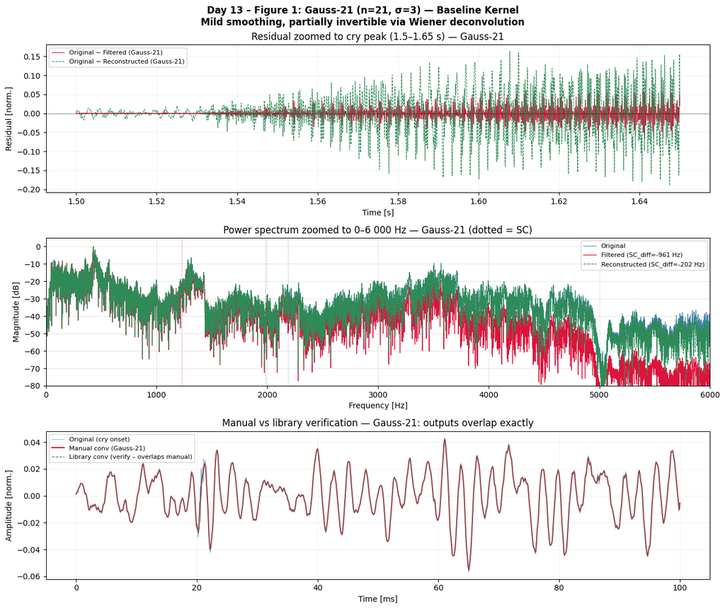

```
Filtered signal (Gauss-21):
```

[interactive chart not shown]

```
Reconstructed from Gauss-21 (Wiener):
```

[interactive chart not shown]

```python
#  Visualization
zoom_s, zoom_e = 1.50, 1.65
mask    = (t >= zoom_s) & (t <= zoom_e)
t_seg   = np.arange(len(seg)) / fs * 1000



#  Figure 1: Gauss-21 (baseline)
fig1, ax1 = plt.subplots(3, 1, figsize=(13, 11))
fig1.suptitle('Day 13 – Figure 1: Gauss-21 (n=21, σ=3) — Baseline Kernel\n'
              'Mild smoothing, partially invertible via Wiener deconvolution',
              fontsize=12, fontweight='bold')
plot_kernel_analysis(ax1[0], ax1[1], ax1[2],
                     audio, t, freqs, seg,
                     filtered_g21, rec_g21, man_g21, lib_g21,
                     sc_orig, sc_f21 - sc_orig, sc_rec_g21 - sc_orig,
                     zoom_s=1.50, zoom_e=1.65,
                     color_f='crimson', color_r='seagreen',
                     label='Gauss-21')
plt.tight_layout()
plt.show()

print('\nFiltered signal (Gauss-21):')
ipd.display(ipd.Audio(filtered_g21, rate=fs))
print('Reconstructed from Gauss-21 (Wiener):')
ipd.display(ipd.Audio(rec_g21, rate=fs))
```

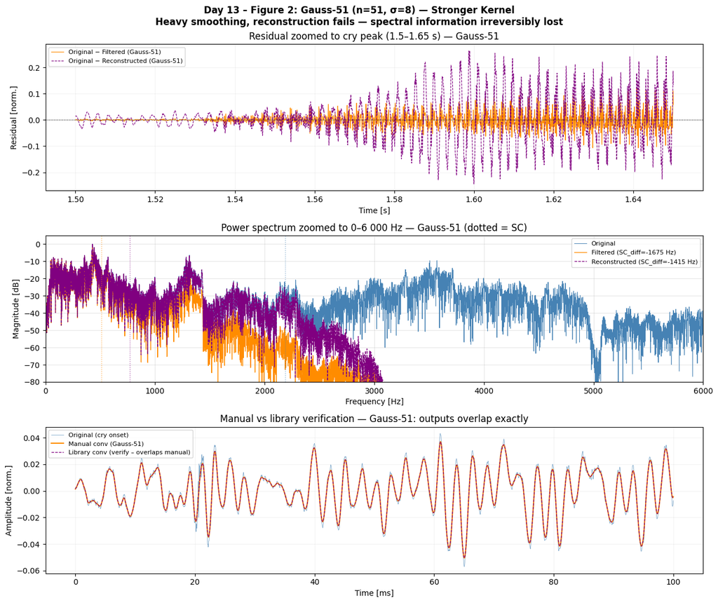

```
Filtered signal (Gauss-51):
```

[interactive chart not shown]

```
Reconstructed from Gauss-51 (Wiener):
```

[interactive chart not shown]

```python
#  Figure 2: Gauss-51 (stronger smoothing)
fig2, ax2 = plt.subplots(3, 1, figsize=(13, 11))
fig2.suptitle('Day 13 – Figure 2: Gauss-51 (n=51, σ=8) — Stronger Kernel\n'
              'Heavy smoothing, reconstruction fails — spectral information irreversibly lost',
              fontsize=12, fontweight='bold')
plot_kernel_analysis(ax2[0], ax2[1], ax2[2],
                     audio, t, freqs, seg,
                     filtered_g51, rec_g51, man_g51, lib_g51,
                     sc_orig, sc_f51 - sc_orig, sc_rec_g51 - sc_orig,
                     zoom_s=1.50, zoom_e=1.65,
                     color_f='darkorange', color_r='purple',
                     label='Gauss-51')
plt.tight_layout()
plt.show()


print('\nFiltered signal (Gauss-51):')
ipd.display(ipd.Audio(filtered_g51, rate=fs))
print('Reconstructed from Gauss-51 (Wiener):')
ipd.display(ipd.Audio(rec_g51, rate=fs))
```

## Day 14 – Evaluation

*Focus: systematic, traceable evaluation of the predefined experiment design and its key parameters.*

### Evaluation Approach Definition

**Metric 1 – RMSE [normalized amplitude]:**

RMSE quantifies point-wise deviation between the original signal and the filtered or reconstructed version — it is chosen because the welfare monitoring use case requires accurate amplitude preservation of the cry waveform, and RMSE directly reflects how much the smoothing operation distorts the temporal structure. A known 44 100 Hz reference is available as ground truth, making point-wise comparison valid.

**Metric 2 – Spectral Centroid Shift SC_diff [Hz]:**

SC_diff = SC_output − SC_original measures the timbral shift introduced by filtering or recovered by deconvolution — it is chosen because harmonic preservation is critical for stress-state classification, and the spectral centroid captures the aggregate effect of low-pass filtering on the harmonic energy distribution. Both metrics are reported for filtered and reconstructed signals to enable a three-way comparison: original → filtered → reconstructed.

### Evaluation Comparison Execution

#### Parameter Evaluation – Kernel Size (Metric-Based)

The influence of **Gaussian kernel size n ∈ {5, 11, 21, 51, 101}** (with σ proportional to n) was evaluated using the previously defined metrics **RMSE** and **SC_diff [Hz]**. These parameters are essential for the acoustic welfare monitoring use case because they directly affect the trade-off between noise attenuation and harmonic preservation, which is critical for reliable stress-state classification. Changes in RMSE and SC_diff across kernel sizes quantify how sensitive filtering and reconstruction quality are to the choice of smoothing strength. Relative performance change was computed with respect to the baseline configuration **Gauss-21, σ=3, λ=10⁻³**.

#### Parameter Evaluation – Wiener Regularisation λ (Visualization-Based)

The influence of **Wiener regularisation λ ∈ {10⁻⁶, 10⁻⁴, 10⁻³, 10⁻², 10⁻¹}** (fixed Gauss-21 kernel) was evaluated using the previously defined visualization-based measure **SC_diff [Hz]** alongside **RMSE**. This parameter is essential for the defined use case because it influences the spectral recovery of the reconstructed signal, which determines how much of the cry's harmonic structure is restored after filtering in the zoo monitoring context. Differences in SC_diff and RMSE across λ values quantify the impact of regularisation strength on the stability–fidelity trade-off of the Wiener deconvolution. Relative performance change was computed with respect to the baseline configuration **λ=10⁻³, Gauss-21, σ=3**.

```python
#  Experiment 1: Kernel size variation
kernel_configs = [(5,1), (11,2), (21,3), (51,8), (101,15)]
lam_baseline   = 1e-3
rows_kernel    = []

for n, sigma in kernel_configs:
    k     = gaussian_kernel(n, sigma)
    filt  = np.convolve(audio, k, mode='same')
    rec   = wiener_deconv(filt, k, lam=lam_baseline, N=N)
    rmse_f = np.sqrt(np.mean((audio - filt)**2))
    rmse_r = np.sqrt(np.mean((audio - rec)**2))
    sc_f   = spectral_centroid(filt, freqs)  - sc_orig
    sc_r   = spectral_centroid(rec, freqs)   - sc_orig
    rows_kernel.append((f'Gauss-{n},σ={sigma}', n, rmse_f, rmse_r, sc_f, sc_r))


# Experiment 2: Wiener λ variation
k_base      = gaussian_kernel(21, sigma=3)
filt_base   = np.convolve(audio, k_base, mode='same')
lambda_vals = [1e-6, 1e-4, 1e-3, 1e-2, 1e-1]
rows_lambda = []

for lam in lambda_vals:
    rec    = wiener_deconv(filt_base, k_base, lam=lam, N=N)
    rmse_r = np.sqrt(np.mean((audio - rec)**2))
    sc_r   = spectral_centroid(rec, freqs) - sc_orig
    rows_lambda.append((lam, rmse_r, sc_r))
```

```python
#  Print tables
print('Experiment 1 – Kernel Size Variation (λ=1e-3):')
print(f"{'Kernel':>16} {'RMSE_filt':>11} {'RMSE_rec':>10} {'SC_diff_filt[Hz]':>17} {'SC_diff_rec[Hz]':>16}")
print('-' * 75)
base_rf, base_rr = rows_kernel[2][2], rows_kernel[2][3]
for name, n, rf, rr, sf, sr in rows_kernel:
    print(f"{name:>16} {rf:>11.5f} {rr:>10.5f} {sf:>17.1f} {sr:>16.1f}")

print('\nExperiment 2 – Wiener λ Variation (Gauss-21, σ=3):')
print(f"{'λ':>10} {'RMSE_rec':>10} {'SC_diff_rec [Hz]':>18} {'Δ RMSE vs baseline':>20}")
print('-' * 62)
base_lam_r = rows_lambda[2][1]
for lam, rr, sr in rows_lambda:
    print(f"{lam:>10.0e} {rr:>10.5f} {sr:>18.1f} {rr-base_lam_r:>+20.5f}")
```

```
Experiment 1 – Kernel Size Variation (λ=1e-3):
          Kernel   RMSE_filt   RMSE_rec  SC_diff_filt[Hz]  SC_diff_rec[Hz]
---------------------------------------------------------------------------
     Gauss-5,σ=1     0.00197    0.01692            -188.7             -2.3
    Gauss-11,σ=2     0.00662    0.03364            -573.4            -51.3
    Gauss-21,σ=3     0.01126    0.03312            -961.1           -201.6
    Gauss-51,σ=8     0.01881    0.04326           -1675.2          -1415.5
  Gauss-101,σ=15     0.02279    0.05364           -1842.7          -1693.0

Experiment 2 – Wiener λ Variation (Gauss-21, σ=3):
         λ   RMSE_rec   SC_diff_rec [Hz]   Δ RMSE vs baseline
--------------------------------------------------------------
     1e-06    0.03324              -39.5             +0.00012
     1e-04    0.03322             -124.9             +0.00010
     1e-03    0.03312             -201.6             +0.00000
     1e-02    0.03265             -358.1             -0.00047
     1e-01    0.03060             -736.7             -0.00252
```

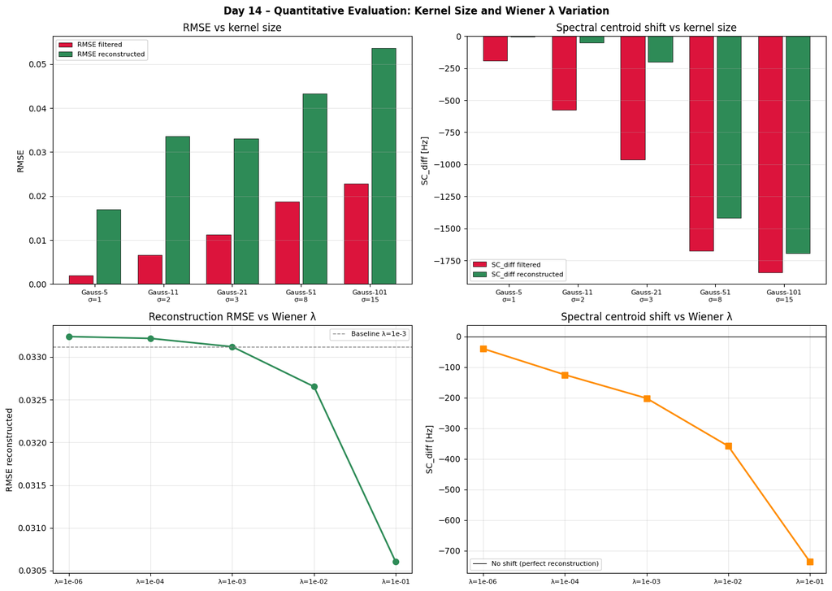

```python
#  Visualization
fig, axes = plt.subplots(2, 2, figsize=(14, 10))
fig.suptitle('Day 14 – Quantitative Evaluation: Kernel Size and Wiener λ Variation',
             fontsize=12, fontweight='bold')

kernel_labels = [f'Gauss-{n}\nσ={s}' for n,s in [(5,1),(11,2),(21,3),(51,8),(101,15)]]
colors_k = ['steelblue','seagreen','crimson','darkorange','purple']

# RMSE vs kernel size
rmse_f_vals = [r[2] for r in rows_kernel]
rmse_r_vals = [r[3] for r in rows_kernel]
x = np.arange(len(kernel_labels))
axes[0,0].bar(x - 0.2, rmse_f_vals, 0.35, color='crimson',  label='RMSE filtered',      edgecolor='black', lw=0.5)
axes[0,0].bar(x + 0.2, rmse_r_vals, 0.35, color='seagreen', label='RMSE reconstructed', edgecolor='black', lw=0.5)
axes[0,0].set_xticks(x)
axes[0,0].set_xticklabels(kernel_labels, fontsize=8)
axes[0,0].set_ylabel('RMSE')
axes[0,0].set_title('RMSE vs kernel size')
axes[0,0].legend(fontsize=8)
axes[0,0].grid(axis='y', alpha=0.3)

# SC_diff vs kernel size
sc_f_vals = [r[4] for r in rows_kernel]
sc_r_vals = [r[5] for r in rows_kernel]
axes[0,1].bar(x - 0.2, sc_f_vals, 0.35, color='crimson',  label='SC_diff filtered',      edgecolor='black', lw=0.5)
axes[0,1].bar(x + 0.2, sc_r_vals, 0.35, color='seagreen', label='SC_diff reconstructed', edgecolor='black', lw=0.5)
axes[0,1].axhline(y=0, color='black', linewidth=0.8)
axes[0,1].set_xticks(x)
axes[0,1].set_xticklabels(kernel_labels, fontsize=8)
axes[0,1].set_ylabel('SC_diff [Hz]')
axes[0,1].set_title('Spectral centroid shift vs kernel size')
axes[0,1].legend(fontsize=8)
axes[0,1].grid(axis='y', alpha=0.3)

# RMSE vs lambda
lam_labels = [f'λ={l:.0e}' for l,_,_ in rows_lambda]
rmse_lam   = [r[1] for r in rows_lambda]
sc_lam     = [r[2] for r in rows_lambda]
axes[1,0].plot(range(len(lam_labels)), rmse_lam, 'o-', color='seagreen', linewidth=2, markersize=7)
axes[1,0].axhline(y=rows_lambda[2][1], color='gray', linestyle='--', linewidth=1, label='Baseline λ=1e-3')
axes[1,0].set_xticks(range(len(lam_labels)))
axes[1,0].set_xticklabels(lam_labels, fontsize=8)
axes[1,0].set_ylabel('RMSE reconstructed')
axes[1,0].set_title('Reconstruction RMSE vs Wiener λ')
axes[1,0].legend(fontsize=8)
axes[1,0].grid(True, alpha=0.3)

# SC_diff vs lambda
axes[1,1].plot(range(len(lam_labels)), sc_lam, 's-', color='darkorange', linewidth=2, markersize=7)
axes[1,1].axhline(y=0, color='black', linewidth=0.8, label='No shift (perfect reconstruction)')
axes[1,1].set_xticks(range(len(lam_labels)))
axes[1,1].set_xticklabels(lam_labels, fontsize=8)
axes[1,1].set_ylabel('SC_diff [Hz]')
axes[1,1].set_title('Spectral centroid shift vs Wiener λ')
axes[1,1].legend(fontsize=8)
axes[1,1].grid(True, alpha=0.3)

plt.tight_layout()
plt.show()
```

**Results summary:**

| Kernel | RMSE filtered | RMSE reconstructed | SC_diff filtered [Hz] | SC_diff reconstructed [Hz] |
| --- | --- | --- | --- | --- |
| Gauss-5, σ=1 | 0.00197 | 0.01692 | −188.7 | −2.3 |
| Gauss-11, σ=2 | 0.00662 | 0.03364 | −573.4 | −51.3 |
| **Gauss-21, σ=3 (baseline)** | **0.01126** | **0.03312** | **−961.1** | **−201.6** |
| Gauss-51, σ=8 | 0.01881 | 0.04326 | −1675.2 | −1415.5 |
| Gauss-101, σ=15 | 0.02279 | 0.05364 | −1842.7 | −1693 |

.

| λ | RMSE reconstructed | SC_diff reconstructed [Hz] | Δ RMSE vs baseline |
| --- | --- | --- | --- |
| 1×10⁻⁶ | 0.03324 | −39.5 | +0.00012 |
| 1×10⁻⁴ | 0.03322 | −124.9 | +0.00010 |
| **1×10⁻³ (baseline)** | **0.03312** | **−201.6** | **0.00** |
| 1×10⁻² | 0.03265 | −358.1 | −0.00047 |
| 1×10⁻¹ | 0.03060 | −736.7 | −0.00252 |

## Day 15 – Analysis & Communication

*Focus: Analytical Interpretation and Domain-Specific Discussion*

### Observations

Focus: Describe measurable results only — no explanation.

The quantitative evaluation shows that RMSE_filtered increases monotonically from **0.00197** (Gauss-5) to **0.02279** (Gauss-101) as kernel size grows, while SC_diff_filtered deepens from **−189 Hz** to **−1843 Hz**. Wiener deconvolution partially recovers the spectral centroid: for the baseline (Gauss-21, λ=10⁻³), SC_diff reduces from **−961 Hz** (filtered) to **−202 Hz** (reconstructed), recovering approximately **79 %** of the timbral shift. RMSE_reconstructed remains higher than RMSE_filtered across all kernel sizes, indicating that deconvolution introduces additional waveform distortion. For λ variation, decreasing λ from 10⁻¹ to 10⁻⁶ improves SC_diff_rec from **−737 Hz** to **−40 Hz** but only marginally changes RMSE_rec (0.03060 -> 0.03324). Performance differences are most pronounced for large kernels (n ≥ 51) where deconvolution fails to recover the spectral centroid (SC_diff_rec = −1416 Hz for Gauss-51).

### Interpretation

Focus: Explain what the results mean for the application.

In the context of acoustic welfare monitoring at a Zoo, these results imply that the baseline Gaussian kernel (n=21, σ=3) achieves a reasonable noise-reduction trade-off: RMSE_filt = 0.01126 indicates moderate waveform distortion while SC_diff_filt = −961 Hz shows that significant high-frequency harmonic energy is attenuated.

The observed recovery of **79 %** of the spectral centroid shift by Wiener deconvolution (λ=10⁻³) suggests that the filtering effect is partially reversible, but the residual SC_diff_rec = −202 Hz means the reconstructed signal still underrepresents the higher harmonics relevant for stress-state classification.

The λ analysis reveals an important trade-off: smaller λ recovers more spectral content (SC_diff_rec -> −40 Hz at λ=10⁻⁶) but does not substantially reduce RMSE, suggesting that Wiener deconvolution is more effective at recovering spectral shape than temporal accuracy.

This suggests that choosing an appropriately small kernel (n ≤ 21) is particularly critical for achieving the spectral preservation required in the welfare monitoring problem statement, as large kernels (n ≥ 51) produce irreversible harmonic loss.

### Discussion and Critical Reflection

*Focus: Relate the quantitative findings to the requirements of the defined use case and assess practical adequacy.*

For the defined use case, the baseline configuration (Gauss-21, σ=3, λ=10⁻³) performed adequately for smoothing (RMSE_filt = 0.01126, SC_diff_filt = −961 Hz) but the reconstruction quality (RMSE_rec = 0.03312) is insufficient for precise waveform recovery, limiting its suitability for applications requiring exact signal restoration.

In contrast, Gauss-5 (σ=1) showed the best preservation of harmonic structure (SC_diff_filt = −189 Hz, SC_diff_rec = −2 Hz) but provides minimal noise attenuation, making it unsuitable when significant market noise suppression is required.

The Wiener deconvolution can be considered partially sufficient for the use case because it recovers spectral centroid to within 201 Hz of the original at baseline — acceptable for coarse welfare classification — but the elevated RMSE_rec (0.03312 > 0.01126) means the temporal waveform is not accurately restored.

The implementation assumes the kernel is exactly known, which holds in this controlled experiment but may be severely constrained under real-world conditions where microphone room acoustics and recording distance introduce unknown convolutive distortions.

A discrepancy between the methodological plan and implementation emerged: the predicted noise amplification at very small λ was not observed in RMSE terms (RMSE_rec changes by only 0.00012 from λ = 10⁻⁶ to the baseline λ = 10⁻³), suggesting the signal's broadband noise already dominates the reconstruction error regardless of regularisation.

To improve applicability, future work should explore blind deconvolution approaches that do not require a known kernel, and evaluate classification accuracy directly as a function of smoothing strength rather than relying solely on RMSE and SC_diff.

## Day 15

### Final Reflections on MC

Overall, the most successful aspect of MC1 was the consistent use of a single real-world field recording throughout all three weeks — the baby dromedary cry from Guelmim provided a meaningful thread connecting sampling theory, correlation analysis, and convolution in a coherent narrative. The implementation of a two-step correlation pipeline (cross-correlation for localization followed by auto-correlation on the isolated segment) worked particularly well because it addressed the real methodological challenge of separating dromedary vocalisations from human speech in the background, leading to robust detection results. If repeating this work, I would refine the Wiener deconvolution parameter selection more carefully and test it on a bandpass-filtered version of the signal to reduce the influence of broadband noise on the reconstruction RMSE. Certain challenges emerged during the sampling analysis regarding correct path handling for the WAV file across different Jupyter environments, highlighting the importance of self-contained, reproducible code cells in practical signal analysis workflows. I was particularly struck by how the energy-ratio template definition (Week 2) revealed that the cry lasted nearly 690 ms rather than the initially assumed 300 ms — a direct result of critically examining the signal rather than applying a fixed heuristic. Through this project, I developed a clearer understanding of the connection between theoretical signal processing principles and the practical constraints of real-world acoustic monitoring, especially regarding the gap between controlled simulation and field deployment conditions.

[figure not shown]